# BIN2DCO: HMXB+NSBH

This is the sketch of the plan for a two-folded study using detail binary evolution models. As a first goal, we will try to set new constraints in the different parameters that leads an initial massive binary to become a high-mass X-ray binary (HMXB) which contains a neutron star (NS) as the compact object accretor. This study includes a complete understading of the starting conditions (masses and orbital periods) and also the formation of the NS accompanied by an asymmetric natal-kick. This study would allow a direct contrast with observational data.

On the second part of the work, we will continue the evolution of such HMXB until the formation of a population of double compact object binaries (with two NS, or a black hole, BH). The aim in this case will be connected to the understanding of the low-mass region of the 'stellar graveyard' where there is a lack of compact objects with masses between 3-5 M$_\odot$. We then would be able to map initial-to-final parameters and try to estimate detectable rates with a net of all the gravitational waves detectors that are searching for these events.

### On this presentation

In the following, we will outline the steps we are going to take in order to achieve the goals we have set. We first introduce the initial parameters that defines the grid we are going to explore with detail modelling. When the first compact object is formed, we will also show how we plan to add the asymmetric natal kick using a deterministic approach on top of the statistical nature of the highly-unknown natal kick.

Show Code

```python
# Load modules, set configs and define useful things

# no need to restart kernel when importing modules
%load_ext autoreload
%autoreload 2

# load packages
import os
import sys
import warnings
from IPython.display import Markdown, display
import numpy as np
import matplotlib.pyplot as plt
import matplotlib.gridspec as gridspec
from matplotlib.ticker import FixedLocator

# package for natal-kick study
from biaswise.binary import BinarySystem

# for clarity, no need for warnings
warnings.filterwarnings('ignore')

def printmd(string):
    display(Markdown(string))

def number_of_points(minim, maxim, step):
    '''evaluate the number of points an array in np.linspace will have'''
    return int(1 + (maxim - minim) / step)

def get_3Dgrid(pm_min, pm_max, n_pm, q_min, q_max, dqs, porb_min, porb_max, n_porb):
    '''create the 3D grid of binary parameters'''
    n_pm = int(n_pm); n_porb = int(n_porb)
    pms = np.power(10, np.linspace(np.log10(pm_min), np.log10(pm_max), num=n_pm))
    qs = np.arange(start=q_min, stop=q_max+0.001, step=dqs)
    porbs = np.power(10, np.linspace(np.log10(porb_min), np.log10(porb_max), num=n_porb))
    return pms, qs, porbs

def config_axes(axs):
    '''some configs for the 3D grid'''
    axs[0].set_xscale('log'); axs[1].set_xscale('log')
    axs[2].set_xscale('log'); axs[2].set_yscale('log')
    axs[0].set_ylim(bottom=0.07, top=0.999)
    axs[1].set_ylim(bottom=0.07, top=0.999)
    axs[0].set_xlim(left=9.4, right=170)
    axs[0].set_xticks([10, 100]); axs[0].set_xticklabels(['10', '100'])
    axs[0].xaxis.set_ticklabels([])
    axs[1].set_xlim(left=2, right=3900)
    axs[1].set_xticks([10, 100, 1000]); axs[1].set_xticklabels(['10', '100', r'1000'])
    axs[1].yaxis.set_ticklabels([])
    axs[2].set_xlim(left=9.4, right=170)
    axs[2].set_xticks([10, 100]); axs[2].set_xticklabels(['10', '100'])
    axs[2].set_ylim(bottom=2, top=3900)
    axs[2].set_yticks([10, 100, 1000]); axs[1].set_xticklabels(['10', '100', r'1000'])
    axs[0].set_ylabel('mass-ratio')
    axs[1].set_xlabel(r'orbital period [days]')
    axs[2].set_xlabel(r'primary mass [M$_\odot$]'); axs[2].set_ylabel(r'orbital period [days]')
```

## 1. Initial binary grid

This grid is composed of three parameters: initial masses (primary mass and mass-ratio) and the initial orbital period. Given the nature of the distribution of these parameters coming from observations (e.g., Sana et al. 2012, Moe & Di Stefano 2016), the steps are either linear (mass-ratios, `dqs`) or logarithmic (primary masses, `dlpms`, and orbital periods, `dlps`). We will also consider that they are independent between them so that we can independently sample from each of them:

#### 3D grid of parameters

Show Code

```python
# 3D grid

## steps to take for masses and binaries
dlpms, dqs, dlps = 0.05, 0.05, 0.10

## primary mass limits
pm_min, pm_max = 10, 150

## mass ratio limtits
q_min, q_max = 0.05, 0.95

## orbital period limits
porb_min, porb_max = 3, 3000

## counter number of points for each coordinate
n_pm = number_of_points(np.log10(pm_min), np.log10(pm_max), step=dlpms)
n_q = number_of_points(q_min, q_max, step=dqs)
n_porb = number_of_points(np.log10(porb_min), np.log10(porb_max), step=dlps)

## create 3D grid of parameters
pm, q, porb = get_3Dgrid(pm_min=pm_min, pm_max=pm_max, n_pm=n_pm,
                         q_min=q_min, q_max=q_max, dqs=dqs,
                         porb_min=porb_min, porb_max=porb_max, n_porb=n_porb)

printmd('3D grid of initial binary parameters is bounded in the range:')
printmd('* $M_{}$ $\epsilon$ [{:.2f}, {:.2f}] M$_\\odot$'.format('{\\rm primary}', pm_min, pm_max))
printmd('* $q = {}$ $\epsilon$ [{:.2f}, {:.2f}]'.format('\dfrac{M_{\\rm secondary}}{M_{\\rm primary}}', q_min, q_max))
printmd('* $P_{}$ $\epsilon$ [{:.2f}, {:.2f}] days'.format('{\\rm orb}', porb_min, porb_max))
```

3D grid of initial binary parameters is bounded in the range:

- $M_{\rm primary}$ $\epsilon$ [10.00, 150.00] M$_\odot$

- $q = \dfrac{M_{\rm secondary}}{M_{\rm primary}}$ $\epsilon$ [0.05, 0.95]

- $P_{\rm orb}$ $\epsilon$ [3.00, 3000.00] days

### Grid information

Exploring this 3D space in an extremely detailed manner is practically impossible due to the time spent in computing each of the binary evolution models. This is why we decide to create 2 grids for the same initial parameter limits: one in which the steps are small enough to have a very good coverage of the grid (**dense grid**) and other in which each of the steps is twice as big (**sparse grid**).

Thanks to this approach we will compute less models while still having a good statistical sample and if it is necessary, we will backup to the more detailed grid in regions where we need.

Show Code

```python
# Stepsize to take from the dense grid. This defines the sparse grid
n = 2
```

### 1.1 Figure with initial binary grid

We show here the grids created before: **dense** and **sparse**

Show Code

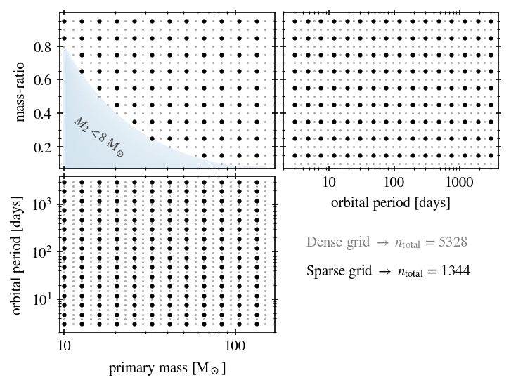

```python
plt.style.use('../config/style.mpl')
fig = plt.figure(figsize=(3.2,3.4))
gs = gridspec.GridSpec(2, 2, figure=fig, bottom=0.09, top=0.982, left=0.12, right=1.42)
ax1 = fig.add_subplot(gs[0,0])
ax2 = fig.add_subplot(gs[0,1])
ax3 = fig.add_subplot(gs[1,0])
axs = [ax1, ax2, ax3]
config_axes(axs)

# plot dense grid
X, Y = np.meshgrid(pm, q)
mask = X * Y >= 8
n_dense_pm = len(X[mask])
ax1.scatter(X[mask], Y[mask], s=0.2, c='gray', zorder=-99, alpha=0.75)
X, Y = np.meshgrid(porb, q)
ax2.scatter(X, Y, s=0.2, c='gray', zorder=-99, alpha=0.75)
X, Y = np.meshgrid(pm, porb)
n_dense_porb = len(porb[::n])
ax3.scatter(X, Y, s=0.2, c='gray', zorder=-99, alpha=0.75)

# plot sparse grid
X, Y = np.meshgrid(pm[::n], q[::n])
mask = X * Y >= 8
n_sparse_pm = len(X[mask])
ax1.scatter(X[mask], Y[mask], s=4, c='black', zorder=99)
X, Y = np.meshgrid(porb[::n], q[::n])
ax2.scatter(X, Y, s=4, c='black', zorder=99)
X, Y = np.meshgrid(pm[::n], porb[::n])
n_sparse_porb = len(porb[::n])
ax3.scatter(X, Y, s=4, c='black', zorder=99)

# number of points in dense & sparse grids
n_sparse = n_sparse_pm * n_sparse_porb
n_dense = n_dense_pm * n_dense_porb

# annotate number of points
msg = 'Dense grid $\\rightarrow$ {} = {}'.format(r'$n_{\rm total}$', n_dense)
fig.text(0.85, 0.33, msg, color='gray')
msg = 'Sparse grid $\\rightarrow$ {} = {}'.format(r'$n_{\rm total}$', n_sparse)
fig.text(0.85, 0.25, msg, color='black')

# annotate region with M2 < 8 Msun
ax1.annotate('$M_2 < 8$ M$_\\odot$', xy=(11, 0.15), rotation=325, color='black', alpha=0.75, fontsize=9)

# fill_between area where M2 < 8 Msun, just for fun
X, Y = np.meshgrid(np.power(10, np.linspace(np.log10(pm_min), np.log10(pm_max), num=n_pm+100)),
                   np.arange(start=q_min, stop=q_max+0.001, step=0.001))
mask = X * Y < 8
ax1.fill_between(X[mask], 0.08, Y[mask], color='C0', alpha=0.10)

plt.subplots_adjust(hspace=0.05, wspace=0.04);
```

## 2. Core collapse stage

Once one of the stars in the binary reaches core-collapse, we will apply an asymmetric kick in order to constraint this unknown event.

This exploration will contain the following assumptions:

- The distribution of natal kick magnitudes are drawn from a maxwellian distribution with a root mean square of 265 km s$^{-1}$ but lowering its value according to the fallback fraction ($f_{\rm b}$) of material that ends up forming the compact object: $v_{\rm kick} = (1 - f_{\rm b}) v_{\rm Maxwell}$
- The post-kick parameters of orbital periods ($P_{\rm orb}$) and eccentricities ($e$) used for the continuation of the binary evolutions are bound to be between the 0.05-0.95 quantiles for $P_{\rm orb}$ and 0.0-1.0 quantiles for $e$
- The grid of post-kick parameters is divided between 10 bins in $P_{\rm orb}$ and 10 bins in $e$

### 2.1 Exemplary case of post-kick orbital parameters

We show an example on how the grid will be divided after the post-kick.

It contains a collapsing star of 12.81 M$_\odot$ forming a BH of 8 M$_\odot$, orbiting around a companion star of 7 M$_\odot$. The fraction of matter falling back to the BH is $f_{\rm b} = 0.5$

Show Code

```python
# create BinarySystem object
binary = BinarySystem(m1=12.81, m1_core_mass=9, m1_remnant_mass=8, m1_fallback_fraction=0.50, m2=7, P=5)

# set the distribution of random kicks. For that, we use a 50000 samples from a Maxwellian distribution scaled
# by the fallback fraction
binary.set_natal_kick_distribution(50000, 'Maxwell', kick_scaling=lambda x: (1-binary.m1_fallback_fraction)*x)

# Then we call the random draws
binary.get_natal_kick_distribution()

# Once the kicks are known, we derived the orbital parameters post kick: Porb, a, e
binary.get_orbital_distribution(True)

# Lastly, we obtain the grid of post-kick parameters
binary.get_post_kick_grid(use_unbounded_for_norm=True, verbose=True)
```

```
calculating post core-collapse orbits for 50000 kicks
	29260 binaries remain bounded
	20740 binaries become unbounded
making grid of orbital configurations
	borders for xaxis (P): 2.62, 214.63 for quantiles [0.05,0.95]
	borders for yaxis (e): 0.01, 1.00 for quantiles [0.00,1.00]
	norm used: 0.585200
```

Show Code

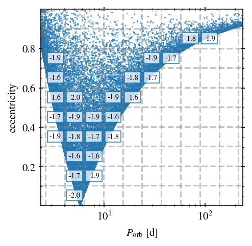

```python
plt.style.use('../config/style.mpl')
fig, ax = plt.subplots(figsize=(3.4,3.4))

# there are several methods to show plots in the BinarySystem, one is the show_post_kick_*
fig, ax = binary.show_post_kick_with_grid('P', 'e', s=0.1, color='C0', fig=fig, ax=ax);
```

As a final comment, the final grid is also written into a file such that the values of $P_{\rm orb}$, $a$ and $e$ can be extracted to then be used in a detail binary evolution